# EDA

#### We can apply Standardisation for scaling but before that we need to see the outliers as Standardisation does not perform well with outliers.

[figure not shown]

```python
plt.figure(figsize=(11,11))
columns = ['TotalSteps','TotalDistance','VeryActiveDistance','ModeratelyActiveDistance','LightActiveDistance','SedentaryActiveDistance',
           'VeryActiveMinutes','LightlyActiveMinutes','SedentaryMinutes']
plotnumber = 1
for feature in columns:
    ax = plt.subplot(3,3,plotnumber)
    df.boxplot(column=feature)
    plt.xlabel(feature)
    plotnumber += 1
plt.tight_layout()
```

#### Since, we have a lot of outliers present in the dataset, we will not use Standardisation/Normalization, whcih will be affected by the presence of outliers. Therefore, we need to use Robust Scaler.

```python
df_2 = df.copy()
df_2.drop(columns=['ActivityDate','Id'],axis=1,inplace=True) # We have dropped 'ActivityDate' and 'Id'because it has datetime values which
                                                        # cannot be fit and transformed using Robust Scaler and 'Id' as
                                                        # are just customer Ids.
```

```python
from sklearn.preprocessing import RobustScaler
scaler = RobustScaler()
```

```python
scaled_data = scaler.fit_transform(df_2)
```

```python
robust_df = pd.DataFrame(scaled_data,columns=df_2.columns)
```

```python
robust_df.head()
```

|  | TotalSteps | TotalDistance | TrackerDistance | LoggedActivitiesDistance | VeryActiveDistance | ModeratelyActiveDistance | LightActiveDistance | SedentaryActiveDistance | VeryActiveMinutes | FairlyActiveMinutes | LightlyActiveMinutes | SedentaryMinutes | Calories | Date |
| --- | --- | --- | --- | --- | --- | --- | --- | --- | --- | --- | --- | --- | --- | --- |
| 0 | 0.611206 | 0.525217 | 0.518010 | 0.0 | 1.961832 | 0.656716 | 0.317549 | 0.0 | 1.32 | 0.6875 | 0.124352 | -0.454219 | -0.272727 | 2.571429 |
| 1 | 1.415713 | 1.297391 | 1.279588 | 0.0 | 5.282443 | 1.059701 | 0.272981 | 0.0 | 3.56 | 1.0000 | 0.481865 | -0.842011 | 0.103255 | 2.714286 |
| 2 | 0.822168 | 0.772174 | 0.761578 | 0.0 | 3.557252 | 0.208955 | 0.217270 | 0.0 | 2.24 | 0.2500 | 0.450777 | -0.811490 | -0.132435 | 2.857143 |
| 3 | 0.882460 | 0.841739 | 0.830189 | 0.0 | 2.435115 | 1.149254 | 0.562674 | 0.0 | 1.56 | 1.1875 | 0.222798 | 0.041293 | -0.145903 | 3.000000 |
| 4 | 0.737515 | 0.653913 | 0.644940 | 0.0 | 1.648855 | 1.597015 | 0.467967 | 0.0 | 1.12 | 1.6875 | 0.321244 | -0.527828 | -0.197531 | 3.142857 |

[figure not shown]

```python
plt.figure(figsize=(11,11))
plotnumber = 1
for feature in robust_df:
    plt.subplot(4,4,plotnumber)
    sns.distplot(robust_df[feature])
    plt.xlabel(feature)
    plotnumber+=1
plt.tight_layout()
```

#### As we can clearly see that even after applying the Robust Scaler, the distributions remain the same. Therefore, we will check with other transformations on the dataset. As a result, we are going to use the algorithms that are not highly dependent upon Normal distribution of the data.

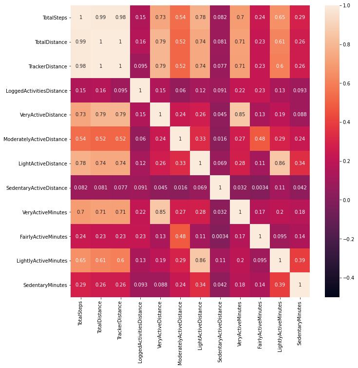

```python
# Checking for colinearity between various features. We are using robust scaled dataset here as outliers affect colinearity
plt.figure(figsize=(11,11))
sns.heatmap(A.corr().abs(),vmin=-0.5,vmax=1,annot=True)
plt.show()
```

##### As per the problem statement, distribution similarity as well as colinearity, the features which are highly colinear are:

##### Totalsteps, TotalDistance and TrackerDistance. Therefore, we can remove TrackerDistance and TotalDistance.

##### LoggedActivitiesDistance and SedentaryActiveDistance can be removed as it has max zero values.

#### Now, checking relationship between independent and dependent features:

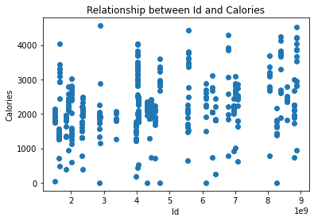

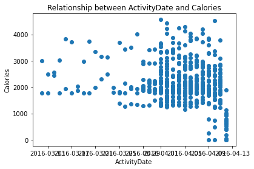

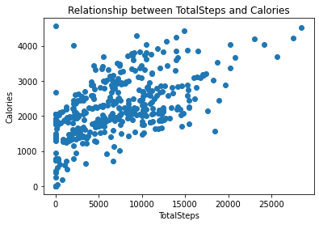

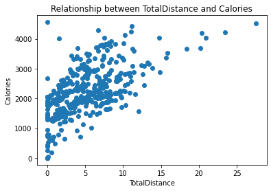

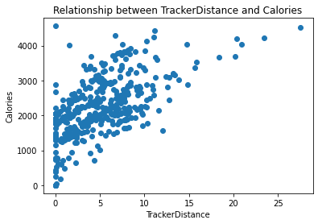

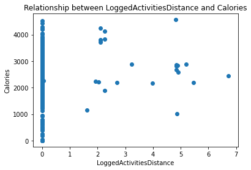

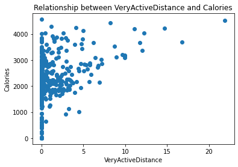

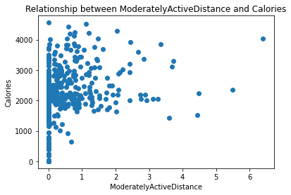

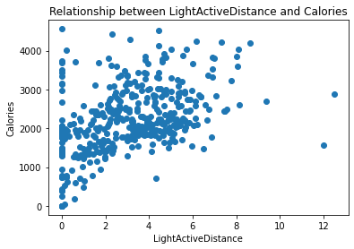

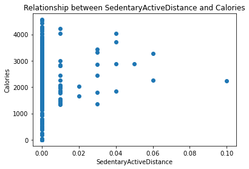

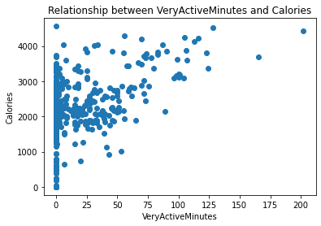

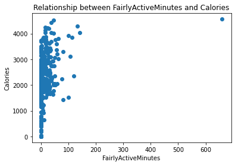

[4 more figures not shown]

```python
for feature in df:
    plt.scatter(df[feature],df['Calories'])
    plt.title(f'Relationship between {feature} and Calories')
    plt.xlabel(feature)
    plt.ylabel('Calories')
    plt.show()
```

#### As we can see here the relationships for 'Totalsteps', 'TotalDistance' and 'TrackerDistance' is with 'Calories' burnt is very similar and features like 'Id', 'ActivityDate' and 'LoggedActivitiesDistance' have almost no proper relationship with 'Calories'.Also, SedentaryActiveDistance has a lot of '0' values. Therefore, according to every analysis till now, we can remove the features:

'TotalDistance'  
'TrackerDistance'  
'Id'  
'ActivityDate'  
'LoggedActivitiesDistance'  
'SedentaryActiveDistance' and  
'Date' (which was just created to see the relationship for Calories burned per day)

```python
# X = robust_df.drop(columns=['TrackerDistance','LoggedActivitiesDistance','Date','Calories'],axis=1)
# y = robust_df['Calories']
```

#### Let's see how the data behaves with various transformations:

```python
#Creating a new dataframe for the transformations:
df_2 = df.drop(columns=['Id','TrackerDistance','TotalDistance','ActivityDate','LoggedActivitiesDistance','Date','SedentaryActiveDistance'],axis=1)
```

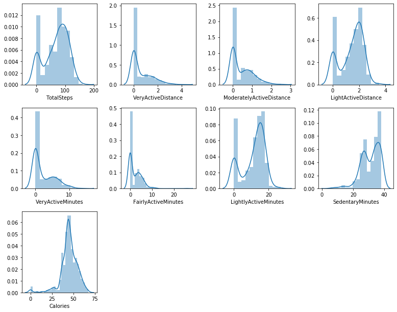

```python
#Square Root Transformation
plt.figure(figsize=(11,11))
plotnumber = 1
for feature in df_2:
    ax = plt.subplot(4,4,plotnumber)
    df_2[feature] = np.sqrt(df_2[feature])
    sns.distplot(df_2[feature])
    plt.xlabel(feature)
    plotnumber+=1
plt.tight_layout()
```

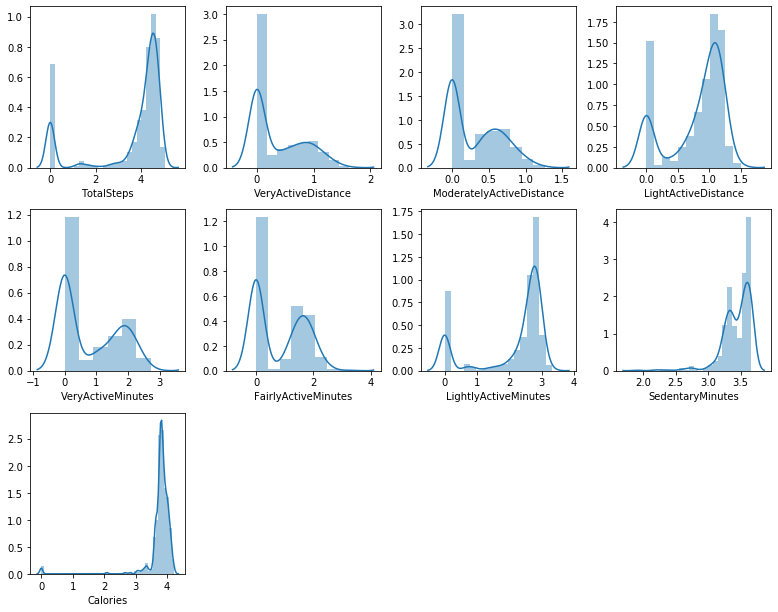

```python
# Logarithmic Transformation
plt.figure(figsize=(11,11))
plotnumber = 1
for feature in df_2:
    ax = plt.subplot(4,4,plotnumber)
    df_2[feature] = np.log(df_2[feature]+1)
    sns.distplot(df_2[feature])
    plt.xlabel(feature)
    plotnumber+=1
plt.tight_layout()
```

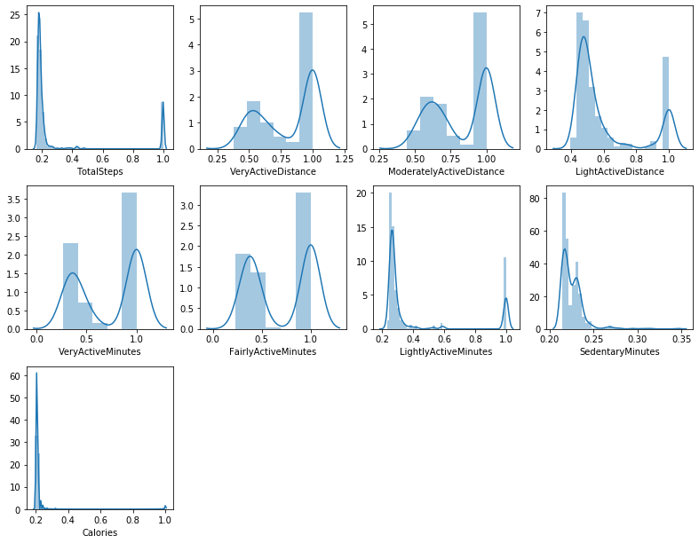

```python
# Reciprocal Transformation
plt.figure(figsize=(11,11))
plotnumber = 1
for feature in df_2:
    ax = plt.subplot(4,4,plotnumber)
    df_2[feature] = 1/(df_2[feature]+1)
    sns.distplot(df_2[feature])
    plt.xlabel(feature)
    plotnumber+=1
plt.tight_layout()
```

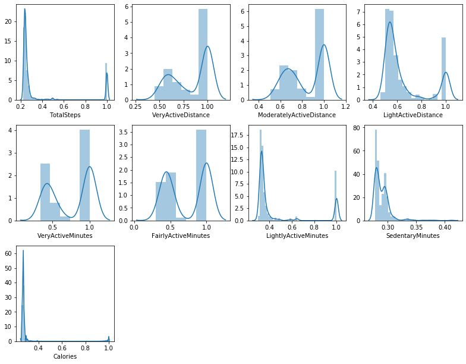

```python
# Exponential Transformation
plt.figure(figsize=(11,11))
plotnumber = 1
for feature in df_2:
    ax = plt.subplot(4,4,plotnumber)
    df_2[feature] = df_2[feature]**(1/1.2)
    sns.distplot(df_2[feature])
    plt.xlabel(feature)
    plotnumber+=1
plt.tight_layout()
```